# Terns spring mass-measurement timing check

Issue #7 - follow-up to issue #5 task 3, per Yosef

2026-09-20

# 1 Background

Yosef doesn’t always have time to weigh/measure every bird he catches - confirmed with Inbal that *which* birds get weighed when time is short is effectively random (whenever he has a free moment), not targeted at particular individuals, so that specific selection concern doesn’t need further checking here.

What this script checks instead: whether **when within the spring season (Mar-May)** the weighed birds were caught has drifted over the years, and if so, whether that drift could be inflating or masking the mass-decline trend already reported in issue #5 task 3 / issue #6.

Scope: spring-caught adults only (juveniles aren’t relevant here, since they’re caught in summer, not spring). **Common Tern** is split into breeder/non-breeder (same definitions as task 3), since #5 found a real mass difference between them. **Little Tern is kept as a single “Adult” group, unsplit** - #5 task 2 found no significant mass difference between Little Tern breeders and non-breeders under either definition (2b: p=0.32-0.62; 2c: p=0.61-0.77), so splitting it here would just be dividing an already small sample (n=184-224 per subgroup) for no analytical benefit.

# 2 Data loading

```r
raw_dir <- "../data_raw"
if (!dir.exists(raw_dir)) raw_dir <- "data_raw"
stopifnot(dir.exists(raw_dir))

proc_dir <- "../data_processed"
if (!dir.exists(proc_dir)) proc_dir <- "data_processed"

out_dir <- "../output"
if (!dir.exists(out_dir)) out_dir <- "output"

ringing_path <- file.path(raw_dir, "ringing_data_raw.xlsx")
stopifnot(file.exists(ringing_path))

col_names_47 <- c(
  "CR1","RingReplace","Rec","RingPrefix","RingNum","Species","Sex","Age","Wing","Weight",
  "Date","Time","Place","Lat","Lon","Ringer","Country","Remarks","Net","CR2","Subsp","Tail","Head",
  "Breeding","CP1","CP2","CP3","CP4","Colour","D","M","OrigDate","OrigCountry","OrigLat","OrigLon","OrigAge",
  "OldCR1","OldCR2","OldCR3","OldMetal1","OldMetal2","OilHead","OilWings","OilUpperP","OilUnderP","OilLegs","OilSum"
)
raw <- read_excel(ringing_path, sheet = "Data", skip = 2, col_names = col_names_47)

terns <- raw %>%
  filter(Species %in% c("STEALB", "STEHIR")) %>%
  mutate(
    year = year(Date),
    month = month(Date),
    date = as.Date(Date),
    ring_id = paste0(trimws(RingPrefix), RingNum),
    is_new = is.na(Rec) | trimws(Rec) == "",
    species_label = ifelse(Species == "STEHIR", "Common Tern", "Little Tern")
  )
```

# 3 Building the spring-adult groups

Identical construction to issue #5 task 3 / `03_mass_trends.Rmd`: confirmed breeder = any spring-caught adult (new ringing or recapture) also recorded in Jun/Jul of **any** year. `day_of_season` = days since March 1 of that year (spring window = Mar-May, so this runs roughly 0-91).

```r
juvenile_ages <- c(1, 3)
summer_ring_ids_anyyear <- terns %>%
  filter(month %in% 6:7) %>%
  distinct(ring_id) %>%
  pull(ring_id)

spring_adults <- terns %>%
  filter(!(Age %in% juvenile_ages), !is.na(Weight), month %in% 3:5) %>%
  mutate(
    confirmed_breeder_anyyear = ring_id %in% summer_ring_ids_anyyear,
    group = case_when(
      species_label == "Little Tern" ~ "Adult",
      confirmed_breeder_anyyear ~ "Adult breeder",
      TRUE ~ "Adult non-breeder"
    ),
    group = factor(group, levels = c("Adult", "Adult non-breeder", "Adult breeder")),
    panel_label = factor(paste(species_label, group, sep = " - "),
                          levels = c("Common Tern - Adult non-breeder", "Common Tern - Adult breeder",
                                     "Little Tern - Adult")),
    day_of_season = as.numeric(date - as.Date(paste0(year, "-03-01")))
  )

kable(
  spring_adults %>% group_by(species_label, group) %>%
    summarise(n = n(), n_years = n_distinct(year), .groups = "drop"),
  caption = "Spring-adult weighed records by species and group"
)
```

Spring-adult weighed records by species and group

| species_label | group | n | n_years |
| --- | --- | --- | --- |
| Common Tern | Adult non-breeder | 1593 | 16 |
| Common Tern | Adult breeder | 490 | 16 |
| Little Tern | Adult | 408 | 16 |

# 4 1. Does mass vary with day-of-season within spring?

Individual-level `Weight ~ day_of_season` regression, per species and group.

```r
within_season_stats <- spring_adults %>%
  group_by(species_label, group, panel_label) %>%
  filter(n() >= 10) %>%
  group_modify(~ {
    m <- lm(Weight ~ day_of_season, data = .x)
    s <- summary(m)
    tibble(
      n = nrow(.x),
      slope_g_per_day = round(coef(m)["day_of_season"], 4),
      se = round(s$coefficients["day_of_season", "Std. Error"], 4),
      p_value = signif(s$coefficients["day_of_season", "Pr(>|t|)"], 3),
      r_squared = round(s$r.squared, 4)
    )
  }) %>%
  ungroup()

kable(within_season_stats, caption = "Weight ~ day_of_season, by species and group")
```

Weight ~ day_of_season, by species and group

| species_label | group | panel_label | n | slope_g_per_day | se | p_value | r_squared |
| --- | --- | --- | --- | --- | --- | --- | --- |
| Common Tern | Adult non-breeder | Common Tern - Adult non-breeder | 1593 | 0.1310 | 0.0204 | 0.0000 | 0.0253 |
| Common Tern | Adult breeder | Common Tern - Adult breeder | 490 | 0.0847 | 0.0352 | 0.0166 | 0.0117 |
| Little Tern | Adult | Little Tern - Adult | 408 | 0.0192 | 0.0205 | 0.3490 | 0.0022 |

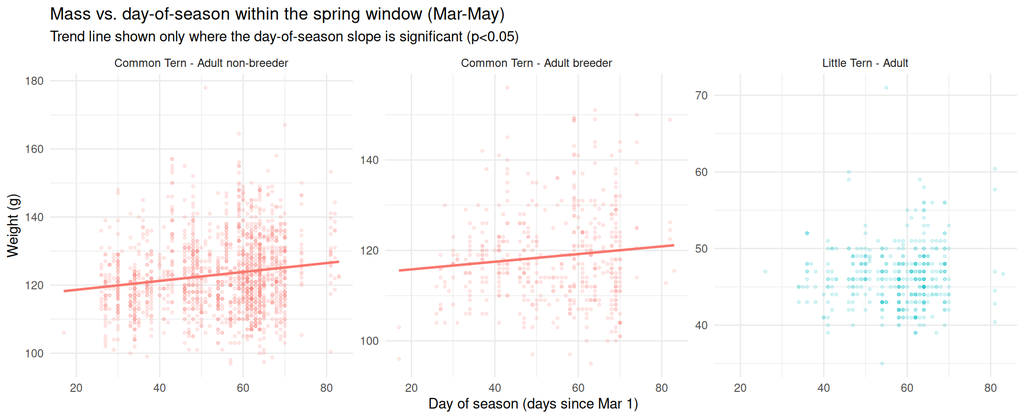

```r
sig_ws <- within_season_stats %>% filter(p_value < 0.05) %>% distinct(panel_label)
spring_adults_sig <- spring_adults %>% semi_join(sig_ws, by = "panel_label")

ggplot(spring_adults, aes(day_of_season, Weight, color = species_label)) +
  geom_point(alpha = 0.15, size = 0.8) +
  geom_smooth(data = spring_adults_sig, method = "lm", se = FALSE, linewidth = 0.9) +
  facet_wrap(~panel_label, ncol = 3, scales = "free_y") +
  guides(color = "none") +
  labs(title = "Mass vs. day-of-season within the spring window (Mar-May)",
       subtitle = "Trend line shown only where the day-of-season slope is significant (p<0.05)",
       x = "Day of season (days since Mar 1)", y = "Weight (g)") +
  theme_minimal()
```

# 5 2. Has the day-of-season of weighed birds shifted over the years?

Individual-level `day_of_season ~ year` regression, per species and group - tests whether recent years’ weighed birds are caught systematically earlier or later in the spring window than early years’.

```r
date_shift_stats <- spring_adults %>%
  group_by(species_label, group, panel_label) %>%
  filter(n() >= 10, n_distinct(year) >= 3) %>%
  group_modify(~ {
    m <- lm(day_of_season ~ year, data = .x)
    s <- summary(m)
    tibble(
      n = nrow(.x),
      n_years = n_distinct(.x$year),
      slope_days_per_year = round(coef(m)["year"], 3),
      se = round(s$coefficients["year", "Std. Error"], 3),
      p_value = signif(s$coefficients["year", "Pr(>|t|)"], 3)
    )
  }) %>%
  ungroup()

kable(date_shift_stats, caption = "day_of_season ~ year, by species and group")
```

day_of_season ~ year, by species and group

| species_label | group | panel_label | n | n_years | slope_days_per_year | se | p_value |
| --- | --- | --- | --- | --- | --- | --- | --- |
| Common Tern | Adult non-breeder | Common Tern - Adult non-breeder | 1593 | 16 | -1.432 | 0.070 | 0.00000 |
| Common Tern | Adult breeder | Common Tern - Adult breeder | 490 | 16 | -0.406 | 0.148 | 0.00635 |
| Little Tern | Adult | Little Tern - Adult | 408 | 16 | -0.863 | 0.130 | 0.00000 |

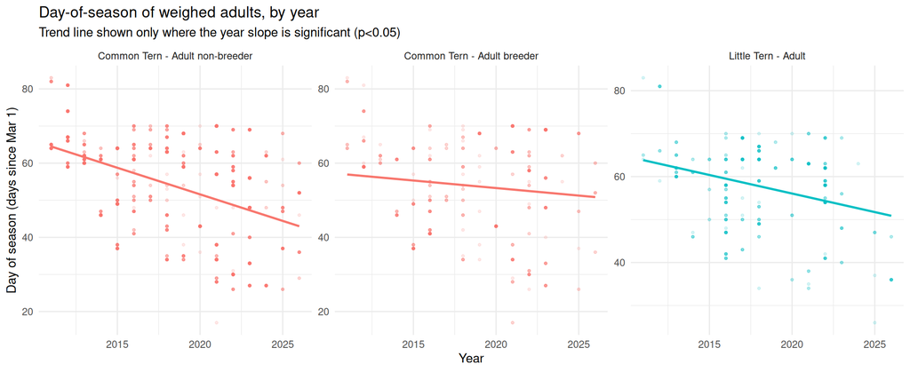

```r
sig_ds <- date_shift_stats %>% filter(p_value < 0.05) %>% distinct(panel_label)
spring_adults_sig_ds <- spring_adults %>% semi_join(sig_ds, by = "panel_label")

ggplot(spring_adults, aes(year, day_of_season, color = species_label)) +
  geom_point(alpha = 0.15, size = 0.8) +
  geom_smooth(data = spring_adults_sig_ds, method = "lm", se = FALSE, linewidth = 0.9) +
  facet_wrap(~panel_label, ncol = 3, scales = "free_y") +
  guides(color = "none") +
  labs(title = "Day-of-season of weighed adults, by year",
       subtitle = "Trend line shown only where the year slope is significant (p<0.05)",
       x = "Year", y = "Day of season (days since Mar 1)") +
  theme_minimal()
```

# 6 3. Could the date shift explain (or mask) the mass-decline trend?

If mass changes by `beta` g per day-of-season (section 1), and the sampling date itself is shifting by `delta` days per year (section 2), the date shift alone would be expected to move the yearly mass average by `beta * delta` g/year - compare this implied contribution against the actual observed mass-decline slope from issue #5 task 3 (`data_processed/mass_trends_stats.csv`, raw mass) to see whether the date shift works with the decline (would partly explain it) or against it (the true decline may be understated). For Little Tern, the comparison uses task 3’s **“All adults (unsplit)”** slope, matching the unsplit `Adult` group used here.

```r
observed_trend <- read.csv(file.path(proc_dir, "mass_trends_stats.csv")) %>%
  filter(group %in% c("Adult breeder", "Adult non-breeder", "All adults (unsplit)")) %>%
  select(species_label, group, observed_slope_g_per_year = slope_g_per_year, observed_p = p_value)

combined_check <- within_season_stats %>%
  select(species_label, group, panel_label, within_season_slope = slope_g_per_day, within_season_p = p_value) %>%
  inner_join(
    date_shift_stats %>% select(species_label, group, date_shift_slope = slope_days_per_year, date_shift_p = p_value),
    by = c("species_label", "group")
  ) %>%
  mutate(implied_contribution_g_per_year = round(within_season_slope * date_shift_slope, 4)) %>%
  mutate(observed_join_group = ifelse(species_label == "Little Tern", "All adults (unsplit)", as.character(group))) %>%
  inner_join(observed_trend, by = c("species_label" = "species_label", "observed_join_group" = "group")) %>%
  select(-observed_join_group) %>%
  mutate(
    pct_of_observed = round(100 * implied_contribution_g_per_year / observed_slope_g_per_year, 1),
    direction = ifelse(sign(implied_contribution_g_per_year) == sign(observed_slope_g_per_year),
                        "Same direction as decline (could partly explain it)",
                        "Opposite direction (works against the decline - true effect may be understated)")
  )

kable(combined_check, digits = 4,
      caption = "Implied contribution of the within-season date shift to the observed yearly mass trend")
```

Implied contribution of the within-season date shift to the observed yearly mass trend

| species_label | group | panel_label | within_season_slope | within_season_p | date_shift_slope | date_shift_p | implied_contribution_g_per_year | observed_slope_g_per_year | observed_p | pct_of_observed | direction |
| --- | --- | --- | --- | --- | --- | --- | --- | --- | --- | --- | --- |
| Common Tern | Adult non-breeder | Common Tern - Adult non-breeder | 0.1310 | 0.0000 | -1.432 | 0.0000 | -0.1876 | -0.173 | 0.0071 | 108.4 | Same direction as decline (could partly explain it) |
| Common Tern | Adult breeder | Common Tern - Adult breeder | 0.0847 | 0.0166 | -0.406 | 0.0063 | -0.0344 | -0.554 | 0.0000 | 6.2 | Same direction as decline (could partly explain it) |
| Little Tern | Adult | Little Tern - Adult | 0.0192 | 0.3490 | -0.863 | 0.0000 | -0.0166 | -0.164 | 0.0036 | 10.1 | Same direction as decline (could partly explain it) |

## 6.1 Interpretation

`implied_contribution_g_per_year` is what you’d expect the date shift alone to contribute to the yearly mass trend, given the within-season mass pattern. Compare its sign and magnitude (`pct_of_observed`) to the actual observed slope: if it points the same direction and is a meaningful share of the observed slope, part of the reported decline could be a timing artifact. If it points the opposite direction, or is a trivial share, the observed decline is not explained by within-season timing drift - if anything, a same-sign-opposing effect means the true condition decline could be slightly *larger* than what’s reported, since the timing shift is working against, not for, the observed pattern.

# 7 Save outputs

```r
write.csv(within_season_stats, file.path(proc_dir, "spring_timing_within_season_stats.csv"), row.names = FALSE)
write.csv(date_shift_stats, file.path(proc_dir, "spring_timing_date_shift_stats.csv"), row.names = FALSE)
write.csv(combined_check, file.path(proc_dir, "spring_timing_combined_check.csv"), row.names = FALSE)
cat("Wrote data_processed/spring_timing_within_season_stats.csv, spring_timing_date_shift_stats.csv, spring_timing_combined_check.csv\n")
```

```
## Wrote data_processed/spring_timing_within_season_stats.csv, spring_timing_date_shift_stats.csv, spring_timing_combined_check.csv
```